# 日期和时间

# 目录

- 1 前提准备
- 2 创建日期/时间
  - 2.1 字符串
  - 2.2 独立的日期-时间元素
  - 2.3 已有的日期/时间对象
- 3 日期-时间元素
  - 3.1 获取日期/时间元素
  - 3.2 约整
  - 3.3 设置日期/时间元素
- 4 时间范围
  - 4.1 Durations
  - 4.2 Periods
  - 4.3 Intervals
  - 4.4 总结
- 5 时区

# 1 前提准备

```r
library(lubridate)
```

```r
library(tidyverse)
```

```r
library(nycflights13)
```

# 2 创建日期/时间

一共有三种日期/时间数据类型：

- **日期（date）**：在 tibble 中显示为 `<date>`
- **时间（time）**：在 tibble 中显示为 `<time>`
- **日期-时间（date-time）**：在 tibble 中显示为 `<dttm>` ，这种数据类型唯一地指代一个时刻

处理时间数据类型需要引入 `hms` 包，在 `lubridate` 包中只关注日期和日期-时间数据类型。

日期-时间数据类型由于要处理时区等问题，复杂程度远高于日期。因此，在满足需要的前提下，尽量使用日期数据类型。

`today()` 可以返回当前的日期：

```r
today()
```

```
[1] "2016-12-19"
```

`now()` 可以返回当前的日期-时间：

```r
now()
```

```
[1] "2016-12-19 00:25:53 CST"
```

除此之外，有3种方式可以创建日期/时间：

- 字符串
- 独立的日期-时间元素
- 已有的日期/时间对象

## 2.1 字符串

使用之前介绍过的 `parse_*()` 函数可以将字符串解析为日期/时间。除此之外，还可以借助 `lubridate` 包中的函数。在这些函数中， `y` 、 `m` 、 `d` 分别指代年、月、日，根据字符串中年月日出现的顺序来排列 `y` 、 `m` 、 `d` ，可以解析日期：

```r
ymd("2017-01-31")
```

```
[1] "2017-01-31"
```

```r
mdy("1, 31, 2017")
```

```
[1] "2017-01-31"
```

```r
dmy("31-Jan-2017")
```

```
[1] "2017-01-31"
```

没有引号的数字也可以被识别：

```r
ymd(20170131)
```

```
[1] "2017-01-31"
```

解析日期-时间：

```r
ymd_hms("2017-01-31 20:11:59")
```

```
[1] "2017-01-31 20:11:59 UTC"
```

```r
mdy_hm("01/31/2017 08:01")
```

```
[1] "2017-01-31 08:01:00 UTC"
```

添加时区参数后，可以将日期转化为日期-时间：

```r
ymd(20170131, tz = "UTC")
```

```
[1] "2017-01-31 UTC"
```

## 2.2 独立的日期-时间元素

有时候日期/时间信息并非存储在单一字符串中，而是分散在数据框的多个列中，如 `flights` 数据集：

```r
flights %>%
  select(year, month, day, hour, minute)
```

| year | month | day | hour | minute |
| --- | --- | --- | --- | --- |
| 2013 | 1 | 1 | 5 | 15 |
| 2013 | 1 | 1 | 5 | 29 |
| 2013 | 1 | 1 | 5 | 40 |
| 2013 | 1 | 1 | 5 | 45 |
| 2013 | 1 | 1 | 6 | 0 |
| 2013 | 1 | 1 | 5 | 58 |
| 2013 | 1 | 1 | 6 | 0 |
| 2013 | 1 | 1 | 6 | 0 |
| 2013 | 1 | 1 | 6 | 0 |
| 2013 | 1 | 1 | 6 | 0 |

[output cut: 990 more lines]

```
#> # A tibble: 336,776 × 5
#>    year month   day  hour minute
#>   <int> <int> <int> <dbl>  <dbl>
#> 1  2013     1     1     5     15
#> 2  2013     1     1     5     29
#> 3  2013     1     1     5     40
#> 4  2013     1     1     5     45
#> 5  2013     1     1     6      0
#> 6  2013     1     1     5     58
#> # ... with 3.368e+05 more rows
```

使用 `make_date()` 创建日期， 使用 `make_datetime()` 创建日期-时间：

```r
flights %>%
  select(year, month, day, hour, minute) %>%
  mutate(departure = make_datetime(year, month, day, hour, minute))
```

| year | month | day | hour | minute | departure |
| --- | --- | --- | --- | --- | --- |
| 2013 | 1 | 1 | 5 | 15 | 2013-01-01 05:15:00 |
| 2013 | 1 | 1 | 5 | 29 | 2013-01-01 05:29:00 |
| 2013 | 1 | 1 | 5 | 40 | 2013-01-01 05:40:00 |
| 2013 | 1 | 1 | 5 | 45 | 2013-01-01 05:45:00 |
| 2013 | 1 | 1 | 6 | 0 | 2013-01-01 06:00:00 |
| 2013 | 1 | 1 | 5 | 58 | 2013-01-01 05:58:00 |
| 2013 | 1 | 1 | 6 | 0 | 2013-01-01 06:00:00 |
| 2013 | 1 | 1 | 6 | 0 | 2013-01-01 06:00:00 |
| 2013 | 1 | 1 | 6 | 0 | 2013-01-01 06:00:00 |
| 2013 | 1 | 1 | 6 | 0 | 2013-01-01 06:00:00 |

[output cut: 990 more lines]

```
#> # A tibble: 336,776 × 6
#>    year month   day  hour minute           departure
#>   <int> <int> <int> <dbl>  <dbl>              <dttm>
#> 1  2013     1     1     5     15 2013-01-01 05:15:00
#> 2  2013     1     1     5     29 2013-01-01 05:29:00
#> 3  2013     1     1     5     40 2013-01-01 05:40:00
#> 4  2013     1     1     5     45 2013-01-01 05:45:00
#> 5  2013     1     1     6      0 2013-01-01 06:00:00
#> 6  2013     1     1     5     58 2013-01-01 05:58:00
#> # ... with 3.368e+05 more rows
```

`flights` 数据集中的4个时间变量用 `2400` 的形式存储数据，对它们进行处理，将之转化为日期-时间数据类型：

```r
make_datetime_100 <- function(year, month, day, time) {
  make_datetime(year, month, day, time %/% 100, time %% 100)
}
flights_dt <- flights %>%
  filter(!is.na(dep_time), !is.na(arr_time)) %>%
  mutate(
    dep_time = make_datetime_100(year, month, day, dep_time),
    arr_time = make_datetime_100(year, month, day, arr_time),
    sched_dep_time = make_datetime_100(year, month, day, sched_dep_time),
    sched_arr_time = make_datetime_100(year, month, day, sched_arr_time)
  ) %>%
  select(origin, dest, ends_with("delay"), ends_with("time"))
flights_dt
```

| origin | dest | dep_delay | arr_delay | dep_time | sched_dep_time | arr_time | sched_arr_time | air_time |
| --- | --- | --- | --- | --- | --- | --- | --- | --- |
| EWR | IAH | 2 | 11 | 2013-01-01 05:17:00 | 2013-01-01 05:15:00 | 2013-01-01 08:30:00 | 2013-01-01 08:19:00 | 227 |
| LGA | IAH | 4 | 20 | 2013-01-01 05:33:00 | 2013-01-01 05:29:00 | 2013-01-01 08:50:00 | 2013-01-01 08:30:00 | 227 |
| JFK | MIA | 2 | 33 | 2013-01-01 05:42:00 | 2013-01-01 05:40:00 | 2013-01-01 09:23:00 | 2013-01-01 08:50:00 | 160 |
| JFK | BQN | -1 | -18 | 2013-01-01 05:44:00 | 2013-01-01 05:45:00 | 2013-01-01 10:04:00 | 2013-01-01 10:22:00 | 183 |
| LGA | ATL | -6 | -25 | 2013-01-01 05:54:00 | 2013-01-01 06:00:00 | 2013-01-01 08:12:00 | 2013-01-01 08:37:00 | 116 |
| EWR | ORD | -4 | 12 | 2013-01-01 05:54:00 | 2013-01-01 05:58:00 | 2013-01-01 07:40:00 | 2013-01-01 07:28:00 | 150 |
| EWR | FLL | -5 | 19 | 2013-01-01 05:55:00 | 2013-01-01 06:00:00 | 2013-01-01 09:13:00 | 2013-01-01 08:54:00 | 158 |
| LGA | IAD | -3 | -14 | 2013-01-01 05:57:00 | 2013-01-01 06:00:00 | 2013-01-01 07:09:00 | 2013-01-01 07:23:00 | 53 |
| JFK | MCO | -3 | -8 | 2013-01-01 05:57:00 | 2013-01-01 06:00:00 | 2013-01-01 08:38:00 | 2013-01-01 08:46:00 | 140 |
| LGA | ORD | -2 | 8 | 2013-01-01 05:58:00 | 2013-01-01 06:00:00 | 2013-01-01 07:53:00 | 2013-01-01 07:45:00 | 138 |

[output cut: 990 more lines]

```
#> # A tibble: 328,063 × 9
#>   origin  dest dep_delay arr_delay            dep_time      sched_dep_time
#>    <chr> <chr>     <dbl>     <dbl>              <dttm>              <dttm>
#> 1    EWR   IAH         2        11 2013-01-01 05:17:00 2013-01-01 05:15:00
#> 2    LGA   IAH         4        20 2013-01-01 05:33:00 2013-01-01 05:29:00
#> 3    JFK   MIA         2        33 2013-01-01 05:42:00 2013-01-01 05:40:00
#> 4    JFK   BQN        -1       -18 2013-01-01 05:44:00 2013-01-01 05:45:00
#> 5    LGA   ATL        -6       -25 2013-01-01 05:54:00 2013-01-01 06:00:00
#> 6    EWR   ORD        -4        12 2013-01-01 05:54:00 2013-01-01 05:58:00
#> # ... with 3.281e+05 more rows, and 3 more variables: arr_time <dttm>,
#> #   sched_arr_time <dttm>, air_time <dbl>
```

可视化出发时间的分布（按天）：

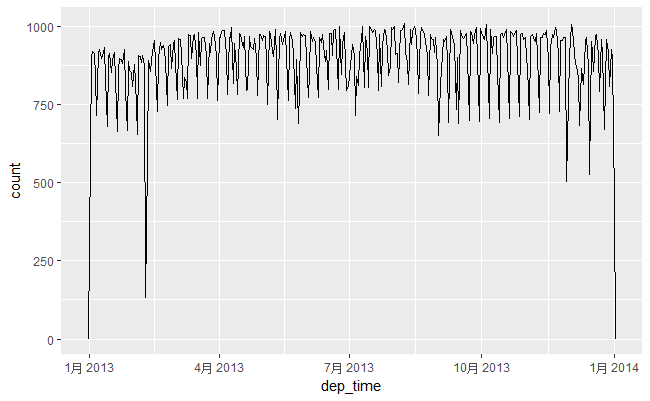

```r
flights_dt %>%
  ggplot(aes(dep_time)) +
  geom_freqpoly(binwidth = 86400) # 86400 seconds = 1 day
```

可视化2013年1月1日这一天，出发时间的分布（按10分钟）：

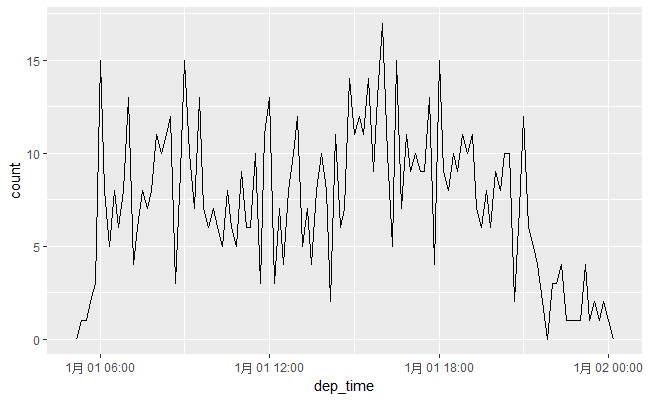

```r
flights_dt %>%
  filter(dep_time < ymd(20130102)) %>%
  ggplot(aes(dep_time)) +
  geom_freqpoly(binwidth = 600) # 600 s = 10 minutes
```

注意，在数值背景下使用日期-时间数据（例如直方图），1代表1秒，所以86400的箱宽代表1天，600的箱宽代表10分钟；对于日期数据，1代表1天。

## 2.3 已有的日期/时间对象

使用 `as_datetime()` 和 `as_date()` 可以在日期和日期-时间格式间转换：

```r
as_datetime(today())
```

```
[1] "2016-12-19 UTC"
```

```r
as_date(now())
```

```
[1] "2016-12-19"
```

如果得到的是从 1970-01-01 起的时间偏移值，按秒计则使用 `as_datetime()` ，按天计则使用 `as_date()` ：

```r
as_datetime(60 * 60 * 10)
```

```
[1] "1970-01-01 10:00:00 UTC"
```

```r
as_date(365 * 10 + 2)
```

```
[1] "1980-01-01"
```

# 3 日期-时间元素

## 3.1 获取日期/时间元素

使用 `year()`, `month()`, `mday()` (day of the month), `yday()` (day of the year), `wday()` (day of the week), `hour()`, `minute()`, `second()` 函数可以获取日期-时间数据中的特定元素：

```r
datetime <- ymd_hms("2016-07-08 12:34:56")
```

```r
year(datetime)
```

```
[1] 2016
```

```r
month(datetime)
```

```
[1] 7
```

```r
mday(datetime)
```

```
[1] 8
```

```r
yday(datetime)
```

```
[1] 190
```

```r
wday(datetime)
```

```
[1] 6
```

对于 `month()` 和 `wday()` ，设置 `label = TRUE` 可以返回别名，再设置 `abbr = FALSE` 可以返回全名：

```r
month(datetime, label = TRUE)
```

```
[1] Jul
Levels: Jan < Feb < Mar < Apr < May < Jun < Jul < Aug < Sep < Oct < Nov < Dec
```

```r
wday(datetime, label = TRUE, abbr = FALSE)
```

```
[1] Friday
Levels: Sunday < Monday < Tuesday < Wednesday < Thursday < Friday < Saturday
```

使用 `wday()` 函数可以看出，工作日的航班比周末的更多：

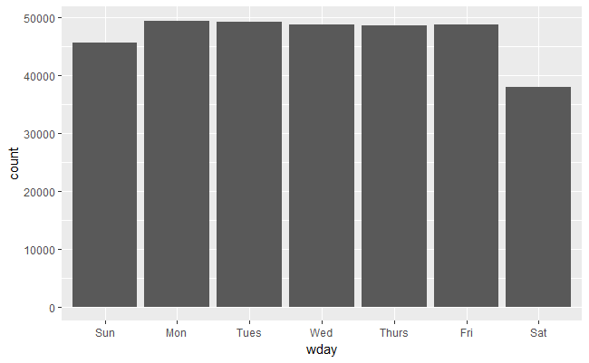

```r
flights_dt %>%
  mutate(wday = wday(dep_time, label = TRUE)) %>%
  ggplot(aes(x = wday)) +
    geom_bar()
```

按航班实际起飞时间的分钟数分组，观察平均延误时间分布，可以看出，在20-30分和50-60分起飞的航班延误时间低得多：

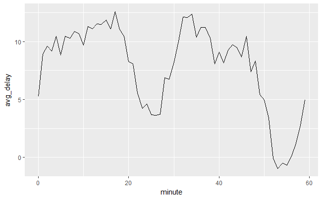

```r
flights_dt %>%
  mutate(minute = minute(dep_time)) %>%
  group_by(minute) %>%
  summarise(
    avg_delay = mean(arr_delay, na.rm = TRUE),
    n = n()) %>%
  ggplot(aes(minute, avg_delay)) +
    geom_line()
```

按航班预定起飞时间的分钟数分组，观察平均延误时间分布，则看不出任何规律：

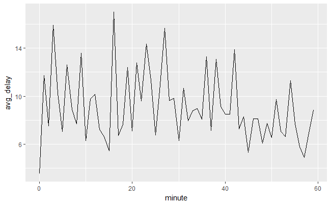

```r
sched_dep <- flights_dt %>%
  mutate(minute = minute(sched_dep_time)) %>%
  group_by(minute) %>%
  summarise(
    avg_delay = mean(arr_delay, na.rm = TRUE),
    n = n())
ggplot(sched_dep, aes(minute, avg_delay)) +
  geom_line()
```

观察航班预定起飞时间的分钟数分布，可以看出，航班倾向于将预定起飞时间安排在整数分钟：

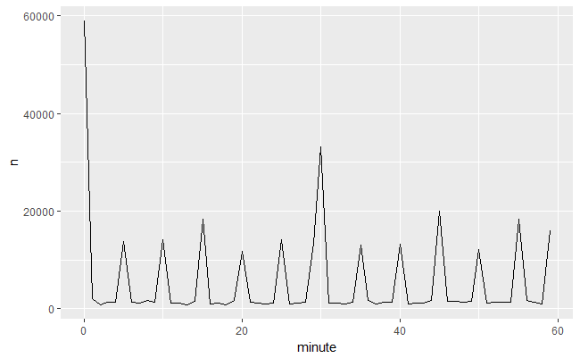

```r
ggplot(sched_dep, aes(minute, n)) +
  geom_line()
```

## 3.2 约整

`floor_date()` 、 `round_date()` 和 `ceiling_date()` 可以对时间进行约整。第一个参数是需要约整的日期-时间向量，第二个参数是需要约整的部分，用字符串形式表达。

按天统计，每一天出发的航班数：

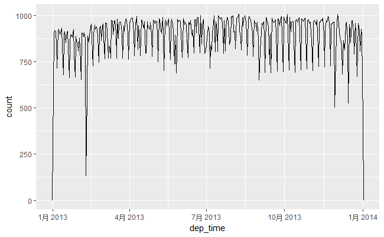

```r
flights_dt %>%
  ggplot(aes(dep_time)) +
  geom_freqpoly(binwidth = 86400) # 86400 seconds = 1 day
```

按周统计，每一周出发的航班数：

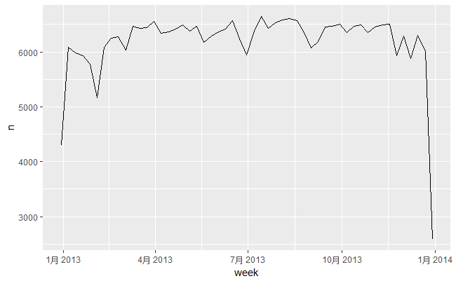

```r
flights_dt %>%
  count(week = floor_date(dep_time, "week")) %>%
  ggplot(aes(week, n)) +
    geom_line()
```

## 3.3 设置日期/时间元素

使用 `year()`, `month()`, `mday()` (day of the month), `yday()` (day of the year), `wday()` (day of the week), `hour()`, `minute()`, `second()` 函数也可以修改日期-时间数据中的特定元素：

```r
(datetime <- ymd_hms("2016-07-08 12:34:56"))
```

```
[1] "2016-07-08 12:34:56 UTC"
```

```r
year(datetime) <- 2020
datetime
```

```
[1] "2020-07-08 12:34:56 UTC"
```

```r
month(datetime) <- 01
datetime
```

```
[1] "2020-01-08 12:34:56 UTC"
```

```r
hour(datetime) <- hour(datetime) + 1
```

以上函数就地修改原有的对象，还可以使用 `update()` 函数在原有对象的基础上创建新的对象：

```r
update(datetime, year = 2020, month = 2, mday = 2, hour = 2)
```

```
[1] "2020-02-02 02:34:56 UTC"
```

如果设置的值过大，会顺延至下个周期：

```r
ymd("2015-02-01") %>%
  update(mday = 30)
```

```
[1] "2015-03-02"
```

```r
ymd("2015-02-01") %>%
  update(hour = 400)
```

```
[1] "2015-02-17 16:00:00 UTC"
```

利用 `update()` 函数将所有航班的 `dep_time` 都设置为2013年1月1日，从而可视化一整年中，航班起飞时间在一天24小时中的分布：

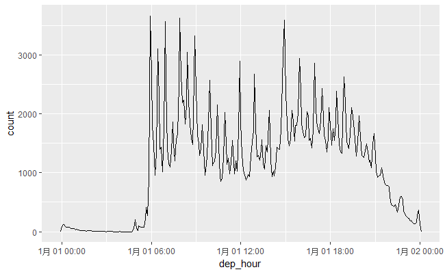

```r
flights_dt %>%
  mutate(dep_hour = update(dep_time, yday = 1)) %>%
  ggplot(aes(dep_hour)) +
    geom_freqpoly(binwidth = 300)
```

将日期-时间数据中的某个大时间尺度的元素设置为常数，可以探索小时间尺度上的规律。

# 4 时间范围

有3种类可以表示时间范围：

- **durations** ： represent an exact number of seconds.
- **periods** ： represent human units like weeks and months.
- **intervals** ： represent a starting and ending point.

## 4.1 Durations

在 R 中，如果对两个日期相减，会得到一个 difftime 对象：

```r
# How old is Hadley?
h_age <- today() - ymd(19791014)
h_age
```

```
Time difference of 13581 days
```

difftime 类用秒、分钟、小时、天或周来表示时间范围，容易引起混淆。 `lubridate` 包提供了 **duration** 对象，始终用秒来表示时间范围：

```r
as.duration(h_age)
```

```
[1] "1173398400s (~37.18 years)"
```

有一系列函数可以创建 duration 对象：

```r
dseconds(15)
```

```
[1] "15s"
```

```r
dminutes(10)
```

```
[1] "600s (~10 minutes)"
```

```r
dhours(c(12, 24))
```

```
[1] "43200s (~12 hours)" "86400s (~1 days)"
```

```r
ddays(0:5)
```

```
[1] "0s"                "86400s (~1 days)"  "172800s (~2 days)" "259200s (~3 days)" "345600s (~4 days)"
[6] "432000s (~5 days)"
```

```r
dweeks(3)
```

```
[1] "1814400s (~3 weeks)"
```

```r
dyears(1)
```

```
[1] "31536000s (~52.14 weeks)"
```

可以对 duration 进行加法、乘法计算：

```r
2 * dyears(1)
```

```
[1] "63072000s (~2 years)"
```

```r
dyears(1) + dweeks(12) + dhours(15)
```

```
[1] "38847600s (~1.23 years)"
```

可以用日期/时间对象和 duration 进行加减计算：

```r
tomorrow <- today() + ddays(1)
last_year <- today() - dyears(1)
```

然而，由于 duration 对象用秒存储，可能会得到意想不到的结果：

```r
one_pm <- ymd_hms("2016-03-12 13:00:00", tz = "America/New_York")
one_pm
```

```
[1] "2016-03-12 13:00:00 EST"
```

```r
one_pm + ddays(1)
```

```
[1] "2016-03-13 14:00:00 EDT"
```

由于夏令时，3月12日只有23个小时，所以加上一整天代表的秒数，13点变成了第二天的14点，且时区也发生了变化。

## 4.2 Periods

不同于 duration 精确用秒存储， period 代表人类定义的时间长度，如天、月：

```r
one_pm
```

```
[1] "2016-03-12 13:00:00 EST"
```

```r
one_pm + days(1)
```

```
[1] "2016-03-13 13:00:00 EDT"
```

有一系列函数可以创建 period 对象：

```r
seconds(15)
```

```
[1] "15S"
```

```r
minutes(10)
```

```
[1] "10M 0S"
```

```r
hours(c(12, 24))
```

```
[1] "12H 0M 0S" "24H 0M 0S"
```

```r
days(7)
```

```
[1] "7d 0H 0M 0S"
```

```r
months(1:6)
```

```
[1] "1m 0d 0H 0M 0S" "2m 0d 0H 0M 0S" "3m 0d 0H 0M 0S" "4m 0d 0H 0M 0S" "5m 0d 0H 0M 0S" "6m 0d 0H 0M 0S"
```

```r
weeks(3)
```

```
[1] "21d 0H 0M 0S"
```

```r
years(1)
```

```
[1] "1y 0m 0d 0H 0M 0S"
```

可以对 period 进行加法、乘法计算：

```r
10 * (months(6) + days(1))
```

```
[1] "60m 10d 0H 0M 0S"
```

```r
days(50) + hours(25) + minutes(2)
```

```
[1] "50d 25H 2M 0S"
```

可以用日期/时间对象和 period 进行加减计算，得到的结果和 duration 可能不同：

```r
# A leap year
ymd("2016-01-01") + dyears(1)
```

```
[1] "2016-12-31"
```

```r
ymd("2016-01-01") + years(1)
```

```
[1] "2017-01-01"
```

```r
# Daylight Savings Time
one_pm + ddays(1)
```

```
[1] "2016-03-13 14:00:00 EDT"
```

```r
one_pm + days(1)
```

```
[1] "2016-03-13 13:00:00 EDT"
```

`flights_dt` 数据集中，某些航班由于通宵飞行，显示的到达时间会早于起飞时间：

```r
flights_dt %>%
  filter(arr_time < dep_time)
```

| origin | dest | dep_delay | arr_delay | dep_time | sched_dep_time | arr_time | sched_arr_time | air_time |
| --- | --- | --- | --- | --- | --- | --- | --- | --- |
| EWR | BQN | 9 | -4 | 2013-01-01 19:29:00 | 2013-01-01 19:20:00 | 2013-01-01 00:03:00 | 2013-01-01 00:07:00 | 192 |
| JFK | DFW | 59 | NA | 2013-01-01 19:39:00 | 2013-01-01 18:40:00 | 2013-01-01 00:29:00 | 2013-01-01 21:51:00 | NA |
| EWR | TPA | -2 | 9 | 2013-01-01 20:58:00 | 2013-01-01 21:00:00 | 2013-01-01 00:08:00 | 2013-01-01 23:59:00 | 159 |
| EWR | SJU | -6 | -12 | 2013-01-01 21:02:00 | 2013-01-01 21:08:00 | 2013-01-01 01:46:00 | 2013-01-01 01:58:00 | 199 |
| EWR | SFO | 11 | -14 | 2013-01-01 21:08:00 | 2013-01-01 20:57:00 | 2013-01-01 00:25:00 | 2013-01-01 00:39:00 | 354 |
| LGA | FLL | -10 | -2 | 2013-01-01 21:20:00 | 2013-01-01 21:30:00 | 2013-01-01 00:16:00 | 2013-01-01 00:18:00 | 160 |
| EWR | MCO | 41 | 43 | 2013-01-01 21:21:00 | 2013-01-01 20:40:00 | 2013-01-01 00:06:00 | 2013-01-01 23:23:00 | 143 |
| JFK | LAX | -7 | -24 | 2013-01-01 21:28:00 | 2013-01-01 21:35:00 | 2013-01-01 00:26:00 | 2013-01-01 00:50:00 | 338 |
| EWR | FLL | 49 | 28 | 2013-01-01 21:34:00 | 2013-01-01 20:45:00 | 2013-01-01 00:20:00 | 2013-01-01 23:52:00 | 152 |
| EWR | FLL | -9 | -14 | 2013-01-01 21:36:00 | 2013-01-01 21:45:00 | 2013-01-01 00:25:00 | 2013-01-01 00:39:00 | 154 |

[output cut: 990 more lines]

```
#> # A tibble: 10,633 × 9
#>   origin  dest dep_delay arr_delay            dep_time      sched_dep_time
#>    <chr> <chr>     <dbl>     <dbl>              <dttm>              <dttm>
#> 1    EWR   BQN         9        -4 2013-01-01 19:29:00 2013-01-01 19:20:00
#> 2    JFK   DFW        59        NA 2013-01-01 19:39:00 2013-01-01 18:40:00
#> 3    EWR   TPA        -2         9 2013-01-01 20:58:00 2013-01-01 21:00:00
#> 4    EWR   SJU        -6       -12 2013-01-01 21:02:00 2013-01-01 21:08:00
#> 5    EWR   SFO        11       -14 2013-01-01 21:08:00 2013-01-01 20:57:00
#> 6    LGA   FLL       -10        -2 2013-01-01 21:20:00 2013-01-01 21:30:00
#> # ... with 1.063e+04 more rows, and 3 more variables: arr_time <dttm>,
#> #   sched_arr_time <dttm>, air_time <dbl>
```

通过为这些航班的到达时间加上 `days(1)` 来修复这一问题：

```r
flights_dt <- flights_dt %>%
  mutate(
    overnight = arr_time < dep_time,
    arr_time = arr_time + days(overnight * 1),
    sched_arr_time = sched_arr_time + days(overnight * 1)
  )
flights_dt %>%
  filter(overnight, arr_time < dep_time)
```

| origin | dest | dep_delay | arr_delay | dep_time | sched_dep_time | arr_time | sched_arr_time | air_time | overnight |
| --- | --- | --- | --- | --- | --- | --- | --- | --- | --- |

```
#> # A tibble: 0 × 10
#> # ... with 10 variables: origin <chr>, dest <chr>, dep_delay <dbl>,
#> #   arr_delay <dbl>, dep_time <dttm>, sched_dep_time <dttm>,
#> #   arr_time <dttm>, sched_arr_time <dttm>, air_time <dbl>,
#> #   overnight <lgl>
```

## 4.3 Intervals

由于 duration 用秒精确存储，所以 `dyears(1) / ddays(365)` 的结果一定是1。但是 `years(1) / days(1)` 的结果并不明确，因为我们并不知道这一年是否为闰年：

```r
years(1) / days(1)
```

```
estimate only: convert to intervals for accuracy
```

```
[1] 365.25
```

为了得到更为精确的结果，需要使用 interval 对象。 interval 相当于一个拥有时间起点的 duration 对象：

```
next_year <- today() + years(1)
(today() %--% next_year) / ddays(1)
```

```
#> [1] 365
```

利用整除找到有多少个 period 落在 interval 中：

```
(today() %--% next_year) %/% days(1)
```

```
#> Note: method with signature 'Timespan#Timespan' chosen for function '%/%',
#>  target signature 'Interval#Period'.
#>  "Interval#ANY", "ANY#Period" would also be valid
#> [1] 365
```

## 4.4 总结

尽量使用简单的数据结构。例如：关注的是物理时间，选择 duration ；关注的是人类时间，选择 period ；关注的是一段时间范围有多长，使用 interval 。

下图是不同日期-时间数据结构之间可以进行的算术运算种类：

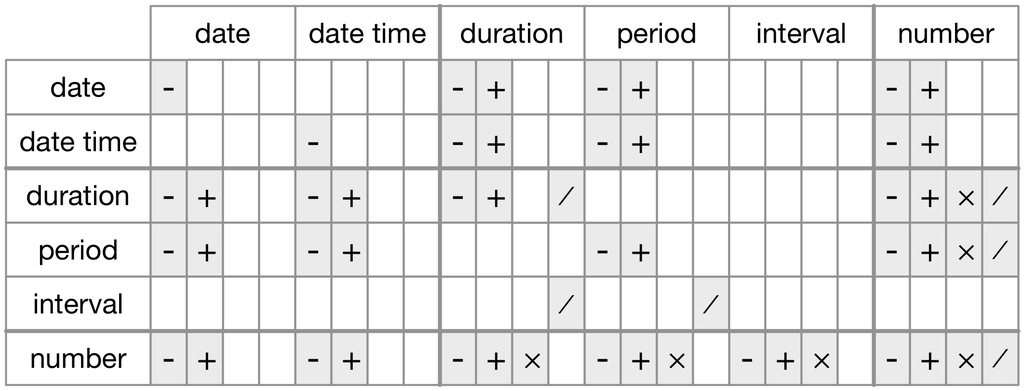

# 5 时区

时区的问题非常复杂，在数据分析领域对这一问题涉及不深。仅需要注意以下几个问题：

使用 `Sys.timezone()` 函数获得系统环境所在的时区：

```r
Sys.timezone()
```

```
[1] "Asia/Taipei"
```

使用 `OlsonNames()` 函数获得完整的时区列表：

```r
length(OlsonNames())
```

```
[1] 589
```

```r
head(OlsonNames())
```

```
[1] "Africa/Abidjan"     "Africa/Accra"       "Africa/Addis_Ababa" "Africa/Algiers"     "Africa/Asmara"
[6] "Africa/Asmera"
```

- 在 R 中，时区是日期-时间数据的属性，仅仅控制显示，而不影响实际时间。例如，以下3个对象实际上表示同一时刻：

```r
(x1 <- ymd_hms("2015-06-01 12:00:00", tz = "America/New_York"))
```

```
[1] "2015-06-01 12:00:00 EDT"
```

```r
(x2 <- ymd_hms("2015-06-01 18:00:00", tz = "Europe/Copenhagen"))
```

```
[1] "2015-06-01 18:00:00 CEST"
```

```r
(x3 <- ymd_hms("2015-06-02 04:00:00", tz = "Pacific/Auckland"))
```

```
[1] "2015-06-02 04:00:00 NZST"
```

通过减法可以验证：

```r
x1 - x2
```

```
Time difference of 0 secs
```

```r
x1 - x3
```

```
Time difference of 0 secs
```

- 默认情况下， `lubridate` 使用协调世界时 UTC (Coordinated Universal Time) 时间，大约等同于其前身格林尼治时间 GMT (Greenwich Mean Time) 。
- 对日期-时间数据使用 `c()` 之类的连接函数，会丢掉原有的时区信息，并显示为系统环境所在的时区：

```r
x4 <- c(x1, x2, x3)
x4
```

```
[1] "2015-06-02 CST" "2015-06-02 CST" "2015-06-02 CST"
```

- 有2种改变时区的方法：

`with_tz` 函数：保持实际时间不变，更改时区参数 `tzone` 。用于实际时间是正确的，仅仅想改变显示的时区的情况：

```r
x4a <- with_tz(x4, tzone = "Australia/Lord_Howe")
x4a
```

```
[1] "2015-06-02 02:30:00 LHST" "2015-06-02 02:30:00 LHST" "2015-06-02 02:30:00 LHST"
```

```r
x4a - x4
```

```
Time differences in secs
[1] 0 0 0
```

`force_tz` 函数：更改实际时间。用于标错了时区的情况：

```r
x4b <- force_tz(x4, tzone = "Australia/Lord_Howe")
x4b
```

```
[1] "2015-06-02 LHST" "2015-06-02 LHST" "2015-06-02 LHST"
```

```r
x4b - x4
```

```
Time differences in hours
[1] -2.5 -2.5 -2.5
```